# Part I - (Ford Gobike Data Exploration)

## Introduction

This project has two parts that demonstrate the importance and value of data visualization techniques in the data analysis process.

In Part I, Exploratory data visualization, you will use Python visualization libraries to systematically explore a selected dataset, starting from plots of single variables and building up to plots of multiple variables. In Part II, Explanatory data visualization, you will produce a short presentation that illustrates interesting properties, trends, and relationships that you discovered in your selected dataset. The primary method of conveying your findings will be through transforming your exploratory visualizations from the first part into polished, explanatory visualizations.

## Ford Gobike Dataset

This dataset includes information about individual rides made in a bike-sharing system covering the greater San Francisco Bay area.

## Preliminary Wrangling

```python
# import all needed packages
import numpy as np
import pandas as pd
import matplotlib.pyplot as plt
import seaborn as sb

%matplotlib inline
```

> Load in your dataset and describe its properties through the questions below. Try and motivate your exploration goals through this section.

```python
# Read the dataset  and show the first rows
df_ford=pd.read_csv('201902-fordgobike-tripdata (3).csv',sep=',')
df_ford.head()
```

|  | duration_sec | start_time | end_time | start_station_id | start_station_name | start_station_latitude | start_station_longitude | end_station_id | end_station_name | end_station_latitude | end_station_longitude | bike_id | user_type | member_birth_year | member_gender | bike_share_for_all_trip |
| --- | --- | --- | --- | --- | --- | --- | --- | --- | --- | --- | --- | --- | --- | --- | --- | --- |
| 0 | 52185 | 2019-02-28 17:32:10.1450 | 2019-03-01 08:01:55.9750 | 21.0 | Montgomery St BART Station (Market St at 2nd St) | 37.789625 | -122.400811 | 13.0 | Commercial St at Montgomery St | 37.794231 | -122.402923 | 4902 | Customer | 1984.0 | Male | No |
| 1 | 42521 | 2019-02-28 18:53:21.7890 | 2019-03-01 06:42:03.0560 | 23.0 | The Embarcadero at Steuart St | 37.791464 | -122.391034 | 81.0 | Berry St at 4th St | 37.775880 | -122.393170 | 2535 | Customer | NaN | NaN | No |
| 2 | 61854 | 2019-02-28 12:13:13.2180 | 2019-03-01 05:24:08.1460 | 86.0 | Market St at Dolores St | 37.769305 | -122.426826 | 3.0 | Powell St BART Station (Market St at 4th St) | 37.786375 | -122.404904 | 5905 | Customer | 1972.0 | Male | No |
| 3 | 36490 | 2019-02-28 17:54:26.0100 | 2019-03-01 04:02:36.8420 | 375.0 | Grove St at Masonic Ave | 37.774836 | -122.446546 | 70.0 | Central Ave at Fell St | 37.773311 | -122.444293 | 6638 | Subscriber | 1989.0 | Other | No |
| 4 | 1585 | 2019-02-28 23:54:18.5490 | 2019-03-01 00:20:44.0740 | 7.0 | Frank H Ogawa Plaza | 37.804562 | -122.271738 | 222.0 | 10th Ave at E 15th St | 37.792714 | -122.248780 | 4898 | Subscriber | 1974.0 | Male | Yes |

## Assessing Data

```python
df_ford.shape
```

```
(183412, 16)
```

```python
df_ford.info()
```

```
<class 'pandas.core.frame.DataFrame'>
RangeIndex: 183412 entries, 0 to 183411
Data columns (total 16 columns):
 #   Column                   Non-Null Count   Dtype
---  ------                   --------------   -----
 0   duration_sec             183412 non-null  int64
 1   start_time               183412 non-null  object
 2   end_time                 183412 non-null  object
 3   start_station_id         183215 non-null  float64
 4   start_station_name       183215 non-null  object
 5   start_station_latitude   183412 non-null  float64
 6   start_station_longitude  183412 non-null  float64
 7   end_station_id           183215 non-null  float64
 8   end_station_name         183215 non-null  object
 9   end_station_latitude     183412 non-null  float64
 10  end_station_longitude    183412 non-null  float64
 11  bike_id                  183412 non-null  int64
 12  user_type                183412 non-null  object
 13  member_birth_year        175147 non-null  float64
 14  member_gender            175147 non-null  object
 15  bike_share_for_all_trip  183412 non-null  object
dtypes: float64(7), int64(2), object(7)
memory usage: 22.4+ MB
```

```python
df_ford.describe()
```

|  | duration_sec | start_station_id | start_station_latitude | start_station_longitude | end_station_id | end_station_latitude | end_station_longitude | bike_id | member_birth_year |
| --- | --- | --- | --- | --- | --- | --- | --- | --- | --- |
| count | 183412.000000 | 183215.000000 | 183412.000000 | 183412.000000 | 183215.000000 | 183412.000000 | 183412.000000 | 183412.000000 | 175147.000000 |
| mean | 726.078435 | 138.590427 | 37.771223 | -122.352664 | 136.249123 | 37.771427 | -122.352250 | 4472.906375 | 1984.806437 |
| std | 1794.389780 | 111.778864 | 0.099581 | 0.117097 | 111.515131 | 0.099490 | 0.116673 | 1664.383394 | 10.116689 |
| min | 61.000000 | 3.000000 | 37.317298 | -122.453704 | 3.000000 | 37.317298 | -122.453704 | 11.000000 | 1878.000000 |
| 25% | 325.000000 | 47.000000 | 37.770083 | -122.412408 | 44.000000 | 37.770407 | -122.411726 | 3777.000000 | 1980.000000 |
| 50% | 514.000000 | 104.000000 | 37.780760 | -122.398285 | 100.000000 | 37.781010 | -122.398279 | 4958.000000 | 1987.000000 |
| 75% | 796.000000 | 239.000000 | 37.797280 | -122.286533 | 235.000000 | 37.797320 | -122.288045 | 5502.000000 | 1992.000000 |
| max | 85444.000000 | 398.000000 | 37.880222 | -121.874119 | 398.000000 | 37.880222 | -121.874119 | 6645.000000 | 2001.000000 |

```python
df_ford.describe(include='O')
```

|  | start_time | end_time | start_station_name | end_station_name | user_type | member_gender | bike_share_for_all_trip |
| --- | --- | --- | --- | --- | --- | --- | --- |
| count | 183412 | 183412 | 183215 | 183215 | 183412 | 175147 | 183412 |
| unique | 183401 | 183397 | 329 | 329 | 2 | 3 | 2 |
| top | 2019-02-25 08:52:07.5820 | 2019-02-11 08:03:22.6020 | Market St at 10th St | San Francisco Caltrain Station 2 (Townsend St... | Subscriber | Male | No |
| freq | 2 | 2 | 3904 | 4857 | 163544 | 130651 | 166053 |

```python
df_ford.isnull().sum()
```

```
duration_sec                  0
start_time                    0
end_time                      0
start_station_id            197
start_station_name          197
start_station_latitude        0
start_station_longitude       0
end_station_id              197
end_station_name            197
end_station_latitude          0
end_station_longitude         0
bike_id                       0
user_type                     0
member_birth_year          8265
member_gender              8265
bike_share_for_all_trip       0
dtype: int64
```

```python
df_ford.duplicated().sum()
```

```
0
```

## Quality & Tidiness issues

##### - There are missing values

##### - Incorrect data types in (start_time - end_time )

##### - Convert member_birth_year to age

##### - Create duration_min and duration_hours

##### - Create new columns for weekdays and months

##### - Dropping users with age more than 60

##### - Dropping uneeded columns

## Cleaning Data

#### Define

Dropping the missing values

#### Code

```python
df_ford = df_ford.dropna()
```

#### Test

```python
df_ford.isnull().sum()
```

```
duration_sec               0
start_time                 0
end_time                   0
start_station_id           0
start_station_name         0
start_station_latitude     0
start_station_longitude    0
end_station_id             0
end_station_name           0
end_station_latitude       0
end_station_longitude      0
bike_id                    0
user_type                  0
member_birth_year          0
member_gender              0
bike_share_for_all_trip    0
dtype: int64
```

#### Define

Converting the data types in the start_time , end_time to datetime

#### Code

```python
df_ford.start_time = pd.to_datetime(df_ford.start_time)
```

```python
df_ford.end_time = pd.to_datetime(df_ford.end_time)
```

#### Test

```python
df_ford.info()
```

```
<class 'pandas.core.frame.DataFrame'>
Int64Index: 174952 entries, 0 to 183411
Data columns (total 16 columns):
 #   Column                   Non-Null Count   Dtype
---  ------                   --------------   -----
 0   duration_sec             174952 non-null  int64
 1   start_time               174952 non-null  datetime64[ns]
 2   end_time                 174952 non-null  datetime64[ns]
 3   start_station_id         174952 non-null  float64
 4   start_station_name       174952 non-null  object
 5   start_station_latitude   174952 non-null  float64
 6   start_station_longitude  174952 non-null  float64
 7   end_station_id           174952 non-null  float64
 8   end_station_name         174952 non-null  object
 9   end_station_latitude     174952 non-null  float64
 10  end_station_longitude    174952 non-null  float64
 11  bike_id                  174952 non-null  int64
 12  user_type                174952 non-null  object
 13  member_birth_year        174952 non-null  float64
 14  member_gender            174952 non-null  object
 15  bike_share_for_all_trip  174952 non-null  object
dtypes: datetime64[ns](2), float64(7), int64(2), object(5)
memory usage: 22.7+ MB
```

#### Define

Create age from member_birth_year and change its data type to int

#### Code

```python
df_ford['age'] = 2022 - df_ford.member_birth_year
```

```python
df_ford.head(1)
```

|  | duration_sec | start_time | end_time | start_station_id | start_station_name | start_station_latitude | start_station_longitude | end_station_id | end_station_name | end_station_latitude | end_station_longitude | bike_id | user_type | member_birth_year | member_gender | bike_share_for_all_trip | age |
| --- | --- | --- | --- | --- | --- | --- | --- | --- | --- | --- | --- | --- | --- | --- | --- | --- | --- |
| 0 | 52185 | 2019-02-28 17:32:10.145 | 2019-03-01 08:01:55.975 | 21.0 | Montgomery St BART Station (Market St at 2nd St) | 37.789625 | -122.400811 | 13.0 | Commercial St at Montgomery St | 37.794231 | -122.402923 | 4902 | Customer | 1984.0 | Male | No | 38.0 |

```python
df_ford.info()
```

```
<class 'pandas.core.frame.DataFrame'>
Int64Index: 174952 entries, 0 to 183411
Data columns (total 17 columns):
 #   Column                   Non-Null Count   Dtype
---  ------                   --------------   -----
 0   duration_sec             174952 non-null  int64
 1   start_time               174952 non-null  datetime64[ns]
 2   end_time                 174952 non-null  datetime64[ns]
 3   start_station_id         174952 non-null  float64
 4   start_station_name       174952 non-null  object
 5   start_station_latitude   174952 non-null  float64
 6   start_station_longitude  174952 non-null  float64
 7   end_station_id           174952 non-null  float64
 8   end_station_name         174952 non-null  object
 9   end_station_latitude     174952 non-null  float64
 10  end_station_longitude    174952 non-null  float64
 11  bike_id                  174952 non-null  int64
 12  user_type                174952 non-null  object
 13  member_birth_year        174952 non-null  float64
 14  member_gender            174952 non-null  object
 15  bike_share_for_all_trip  174952 non-null  object
 16  age                      174952 non-null  float64
dtypes: datetime64[ns](2), float64(8), int64(2), object(5)
memory usage: 24.0+ MB
```

```python
df_ford['age'] = df_ford['age'].astype('Int64')
```

#### Test

```python
df_ford.info()
```

```
<class 'pandas.core.frame.DataFrame'>
Int64Index: 174952 entries, 0 to 183411
Data columns (total 17 columns):
 #   Column                   Non-Null Count   Dtype
---  ------                   --------------   -----
 0   duration_sec             174952 non-null  int64
 1   start_time               174952 non-null  datetime64[ns]
 2   end_time                 174952 non-null  datetime64[ns]
 3   start_station_id         174952 non-null  float64
 4   start_station_name       174952 non-null  object
 5   start_station_latitude   174952 non-null  float64
 6   start_station_longitude  174952 non-null  float64
 7   end_station_id           174952 non-null  float64
 8   end_station_name         174952 non-null  object
 9   end_station_latitude     174952 non-null  float64
 10  end_station_longitude    174952 non-null  float64
 11  bike_id                  174952 non-null  int64
 12  user_type                174952 non-null  object
 13  member_birth_year        174952 non-null  float64
 14  member_gender            174952 non-null  object
 15  bike_share_for_all_trip  174952 non-null  object
 16  age                      174952 non-null  Int64
dtypes: Int64(1), datetime64[ns](2), float64(7), int64(2), object(5)
memory usage: 24.2+ MB
```

#### Define

Create duration_min and duration_hours

#### Code

```python
df_ford['duration_min'] = df_ford.duration_sec/ 60
```

```python
df_ford['duration_hours'] = df_ford.duration_sec/ 3600
```

```python
df_ford.duration_min = df_ford.duration_min.astype('int64')
```

```python
df_ford.duration_hours = df_ford.duration_hours.astype('int64')
```

#### Test

```python
df_ford.head()
```

|  | duration_sec | start_time | end_time | start_station_id | start_station_name | start_station_latitude | start_station_longitude | end_station_id | end_station_name | end_station_latitude | end_station_longitude | bike_id | user_type | member_birth_year | member_gender | bike_share_for_all_trip | age | duration_min | duration_hours |
| --- | --- | --- | --- | --- | --- | --- | --- | --- | --- | --- | --- | --- | --- | --- | --- | --- | --- | --- | --- |
| 0 | 52185 | 2019-02-28 17:32:10.145 | 2019-03-01 08:01:55.975 | 21.0 | Montgomery St BART Station (Market St at 2nd St) | 37.789625 | -122.400811 | 13.0 | Commercial St at Montgomery St | 37.794231 | -122.402923 | 4902 | Customer | 1984.0 | Male | No | 38 | 869 | 14 |
| 2 | 61854 | 2019-02-28 12:13:13.218 | 2019-03-01 05:24:08.146 | 86.0 | Market St at Dolores St | 37.769305 | -122.426826 | 3.0 | Powell St BART Station (Market St at 4th St) | 37.786375 | -122.404904 | 5905 | Customer | 1972.0 | Male | No | 50 | 1030 | 17 |
| 3 | 36490 | 2019-02-28 17:54:26.010 | 2019-03-01 04:02:36.842 | 375.0 | Grove St at Masonic Ave | 37.774836 | -122.446546 | 70.0 | Central Ave at Fell St | 37.773311 | -122.444293 | 6638 | Subscriber | 1989.0 | Other | No | 33 | 608 | 10 |
| 4 | 1585 | 2019-02-28 23:54:18.549 | 2019-03-01 00:20:44.074 | 7.0 | Frank H Ogawa Plaza | 37.804562 | -122.271738 | 222.0 | 10th Ave at E 15th St | 37.792714 | -122.248780 | 4898 | Subscriber | 1974.0 | Male | Yes | 48 | 26 | 0 |
| 5 | 1793 | 2019-02-28 23:49:58.632 | 2019-03-01 00:19:51.760 | 93.0 | 4th St at Mission Bay Blvd S | 37.770407 | -122.391198 | 323.0 | Broadway at Kearny | 37.798014 | -122.405950 | 5200 | Subscriber | 1959.0 | Male | No | 63 | 29 | 0 |

```python
df_ford.info()
```

```
<class 'pandas.core.frame.DataFrame'>
Int64Index: 174952 entries, 0 to 183411
Data columns (total 19 columns):
 #   Column                   Non-Null Count   Dtype
---  ------                   --------------   -----
 0   duration_sec             174952 non-null  int64
 1   start_time               174952 non-null  datetime64[ns]
 2   end_time                 174952 non-null  datetime64[ns]
 3   start_station_id         174952 non-null  float64
 4   start_station_name       174952 non-null  object
 5   start_station_latitude   174952 non-null  float64
 6   start_station_longitude  174952 non-null  float64
 7   end_station_id           174952 non-null  float64
 8   end_station_name         174952 non-null  object
 9   end_station_latitude     174952 non-null  float64
 10  end_station_longitude    174952 non-null  float64
 11  bike_id                  174952 non-null  int64
 12  user_type                174952 non-null  object
 13  member_birth_year        174952 non-null  float64
 14  member_gender            174952 non-null  object
 15  bike_share_for_all_trip  174952 non-null  object
 16  age                      174952 non-null  Int64
 17  duration_min             174952 non-null  int64
 18  duration_hours           174952 non-null  int64
dtypes: Int64(1), datetime64[ns](2), float64(7), int64(4), object(5)
memory usage: 26.9+ MB
```

#### Define

Drop unneeded columns

#### Code

```python
df_ford= df_ford.drop(columns=[ 'start_station_latitude' ,'start_station_longitude', 'end_station_latitude', 'end_station_longitude'])
```

#### Test

```python
df_ford.columns
```

```
Index(['duration_sec', 'start_time', 'end_time', 'start_station_id',
       'start_station_name', 'end_station_id', 'end_station_name', 'bike_id',
       'user_type', 'member_birth_year', 'member_gender',
       'bike_share_for_all_trip', 'age', 'duration_min', 'duration_hours'],
      dtype='object')
```

```python
df_ford.head(1)
```

|  | duration_sec | start_time | end_time | start_station_id | start_station_name | end_station_id | end_station_name | bike_id | user_type | member_birth_year | member_gender | bike_share_for_all_trip | age | duration_min | duration_hours |
| --- | --- | --- | --- | --- | --- | --- | --- | --- | --- | --- | --- | --- | --- | --- | --- |
| 0 | 52185 | 2019-02-28 17:32:10.145 | 2019-03-01 08:01:55.975 | 21.0 | Montgomery St BART Station (Market St at 2nd St) | 13.0 | Commercial St at Montgomery St | 4902 | Customer | 1984.0 | Male | No | 38 | 869 | 14 |

#### Define

Create new columns for weekdays and months for (start_time & end_time)

```python
df_ford.info()
```

```
<class 'pandas.core.frame.DataFrame'>
Int64Index: 174952 entries, 0 to 183411
Data columns (total 15 columns):
 #   Column                   Non-Null Count   Dtype
---  ------                   --------------   -----
 0   duration_sec             174952 non-null  int64
 1   start_time               174952 non-null  datetime64[ns]
 2   end_time                 174952 non-null  datetime64[ns]
 3   start_station_id         174952 non-null  float64
 4   start_station_name       174952 non-null  object
 5   end_station_id           174952 non-null  float64
 6   end_station_name         174952 non-null  object
 7   bike_id                  174952 non-null  int64
 8   user_type                174952 non-null  object
 9   member_birth_year        174952 non-null  float64
 10  member_gender            174952 non-null  object
 11  bike_share_for_all_trip  174952 non-null  object
 12  age                      174952 non-null  Int64
 13  duration_min             174952 non-null  int64
 14  duration_hours           174952 non-null  int64
dtypes: Int64(1), datetime64[ns](2), float64(3), int64(4), object(5)
memory usage: 21.5+ MB
```

#### Code

```python
dayOfWeek_start_time={0:'Monday', 1:'Tuesday', 2:'Wednesday', 3:'Thursday', 4:'Friday', 5:'Saturday', 6:'Sunday'}
df_ford['weekday_st'] = df_ford['start_time'].dt.dayofweek.map(dayOfWeek_start_time)
```

```python
df_ford['day_st']= pd.to_datetime(df_ford.start_time).dt.day
df_ford['hour_st'] = df_ford.start_time.dt.hour
```

```python
df_ford.head()
```

|  | duration_sec | start_time | end_time | start_station_id | start_station_name | end_station_id | end_station_name | bike_id | user_type | member_birth_year | member_gender | bike_share_for_all_trip | age | duration_min | duration_hours | weekday_st | day_st | hour_st |
| --- | --- | --- | --- | --- | --- | --- | --- | --- | --- | --- | --- | --- | --- | --- | --- | --- | --- | --- |
| 0 | 52185 | 2019-02-28 17:32:10.145 | 2019-03-01 08:01:55.975 | 21.0 | Montgomery St BART Station (Market St at 2nd St) | 13.0 | Commercial St at Montgomery St | 4902 | Customer | 1984.0 | Male | No | 38 | 869 | 14 | Thursday | 28 | 17 |
| 2 | 61854 | 2019-02-28 12:13:13.218 | 2019-03-01 05:24:08.146 | 86.0 | Market St at Dolores St | 3.0 | Powell St BART Station (Market St at 4th St) | 5905 | Customer | 1972.0 | Male | No | 50 | 1030 | 17 | Thursday | 28 | 12 |
| 3 | 36490 | 2019-02-28 17:54:26.010 | 2019-03-01 04:02:36.842 | 375.0 | Grove St at Masonic Ave | 70.0 | Central Ave at Fell St | 6638 | Subscriber | 1989.0 | Other | No | 33 | 608 | 10 | Thursday | 28 | 17 |
| 4 | 1585 | 2019-02-28 23:54:18.549 | 2019-03-01 00:20:44.074 | 7.0 | Frank H Ogawa Plaza | 222.0 | 10th Ave at E 15th St | 4898 | Subscriber | 1974.0 | Male | Yes | 48 | 26 | 0 | Thursday | 28 | 23 |
| 5 | 1793 | 2019-02-28 23:49:58.632 | 2019-03-01 00:19:51.760 | 93.0 | 4th St at Mission Bay Blvd S | 323.0 | Broadway at Kearny | 5200 | Subscriber | 1959.0 | Male | No | 63 | 29 | 0 | Thursday | 28 | 23 |

```python
df_ford['hour_et'] = df_ford.end_time.dt.hour
```

#### Test

```python
df_ford.head()
```

|  | duration_sec | start_time | end_time | start_station_id | start_station_name | end_station_id | end_station_name | bike_id | user_type | member_birth_year | member_gender | bike_share_for_all_trip | age | duration_min | duration_hours | weekday_st | day_st | hour_st | hour_et |
| --- | --- | --- | --- | --- | --- | --- | --- | --- | --- | --- | --- | --- | --- | --- | --- | --- | --- | --- | --- |
| 0 | 52185 | 2019-02-28 17:32:10.145 | 2019-03-01 08:01:55.975 | 21.0 | Montgomery St BART Station (Market St at 2nd St) | 13.0 | Commercial St at Montgomery St | 4902 | Customer | 1984.0 | Male | No | 38 | 869 | 14 | Thursday | 28 | 17 | 8 |
| 2 | 61854 | 2019-02-28 12:13:13.218 | 2019-03-01 05:24:08.146 | 86.0 | Market St at Dolores St | 3.0 | Powell St BART Station (Market St at 4th St) | 5905 | Customer | 1972.0 | Male | No | 50 | 1030 | 17 | Thursday | 28 | 12 | 5 |
| 3 | 36490 | 2019-02-28 17:54:26.010 | 2019-03-01 04:02:36.842 | 375.0 | Grove St at Masonic Ave | 70.0 | Central Ave at Fell St | 6638 | Subscriber | 1989.0 | Other | No | 33 | 608 | 10 | Thursday | 28 | 17 | 4 |
| 4 | 1585 | 2019-02-28 23:54:18.549 | 2019-03-01 00:20:44.074 | 7.0 | Frank H Ogawa Plaza | 222.0 | 10th Ave at E 15th St | 4898 | Subscriber | 1974.0 | Male | Yes | 48 | 26 | 0 | Thursday | 28 | 23 | 0 |
| 5 | 1793 | 2019-02-28 23:49:58.632 | 2019-03-01 00:19:51.760 | 93.0 | 4th St at Mission Bay Blvd S | 323.0 | Broadway at Kearny | 5200 | Subscriber | 1959.0 | Male | No | 63 | 29 | 0 | Thursday | 28 | 23 | 0 |

```python
df_ford.shape
```

```
(174952, 19)
```

```python
df_ford.info()
```

```
<class 'pandas.core.frame.DataFrame'>
Int64Index: 174952 entries, 0 to 183411
Data columns (total 19 columns):
 #   Column                   Non-Null Count   Dtype
---  ------                   --------------   -----
 0   duration_sec             174952 non-null  int64
 1   start_time               174952 non-null  datetime64[ns]
 2   end_time                 174952 non-null  datetime64[ns]
 3   start_station_id         174952 non-null  float64
 4   start_station_name       174952 non-null  object
 5   end_station_id           174952 non-null  float64
 6   end_station_name         174952 non-null  object
 7   bike_id                  174952 non-null  int64
 8   user_type                174952 non-null  object
 9   member_birth_year        174952 non-null  float64
 10  member_gender            174952 non-null  object
 11  bike_share_for_all_trip  174952 non-null  object
 12  age                      174952 non-null  Int64
 13  duration_min             174952 non-null  int64
 14  duration_hours           174952 non-null  int64
 15  weekday_st               174952 non-null  object
 16  day_st                   174952 non-null  int64
 17  hour_st                  174952 non-null  int64
 18  hour_et                  174952 non-null  int64
dtypes: Int64(1), datetime64[ns](2), float64(3), int64(7), object(6)
memory usage: 26.9+ MB
```

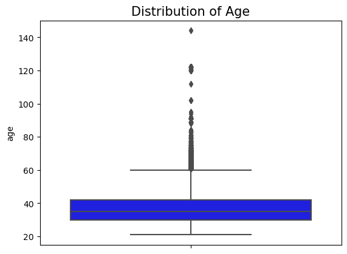

```python
#Plot the distribution of Age
def plot_age(data,y , title):
    sb.boxplot(data=data ,y=y , color ="b")
    plt.xticks(rotation=15);
    plt.title(title , fontsize=15);
plot_age(data=df_ford ,y="age" , title="Distribution of Age") ;
```

### As we can see , most ages of users from 20 to 60 and there are a few outliers above 60 that we need to dropping.

```python
df_ford.age.describe()
```

```
count    174952.000000
mean         37.196865
std          10.118731
min          21.000000
25%          30.000000
50%          35.000000
75%          42.000000
max         144.000000
Name: age, dtype: float64
```

```python
# Remove users over 60 years old
df_ford = df_ford[df_ford['age']<=60]
```

```python
df_ford.age.describe()
```

```
count    169171.000000
mean         36.185558
std           8.518091
min          21.000000
25%          30.000000
50%          35.000000
75%          41.000000
max          60.000000
Name: age, dtype: float64
```

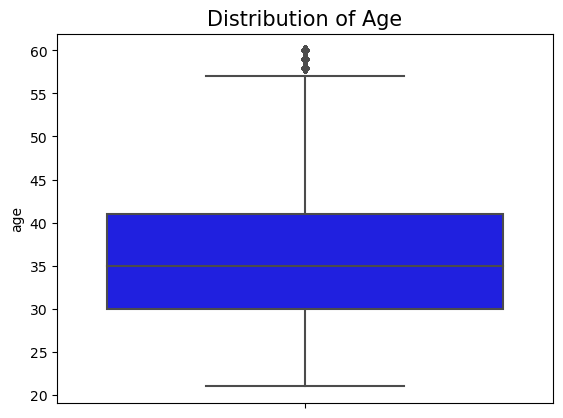

```python
#Plot the distribution of Age
def plot_age_after(data,y , title):
    sb.boxplot(data=data ,y=y , color ="b")
    plt.xticks(rotation=15);
    plt.title(title , fontsize=15);
plot_age_after(data=df_ford ,y="age" , title="Distribution of Age") ;
```

```python
df_ford.shape
```

```
(169171, 19)
```

```python
df_ford.info()
```

```
<class 'pandas.core.frame.DataFrame'>
Int64Index: 169171 entries, 0 to 183411
Data columns (total 19 columns):
 #   Column                   Non-Null Count   Dtype
---  ------                   --------------   -----
 0   duration_sec             169171 non-null  int64
 1   start_time               169171 non-null  datetime64[ns]
 2   end_time                 169171 non-null  datetime64[ns]
 3   start_station_id         169171 non-null  float64
 4   start_station_name       169171 non-null  object
 5   end_station_id           169171 non-null  float64
 6   end_station_name         169171 non-null  object
 7   bike_id                  169171 non-null  int64
 8   user_type                169171 non-null  object
 9   member_birth_year        169171 non-null  float64
 10  member_gender            169171 non-null  object
 11  bike_share_for_all_trip  169171 non-null  object
 12  age                      169171 non-null  Int64
 13  duration_min             169171 non-null  int64
 14  duration_hours           169171 non-null  int64
 15  weekday_st               169171 non-null  object
 16  day_st                   169171 non-null  int64
 17  hour_st                  169171 non-null  int64
 18  hour_et                  169171 non-null  int64
dtypes: Int64(1), datetime64[ns](2), float64(3), int64(7), object(6)
memory usage: 26.0+ MB
```

### What is/are the main feature(s) of interest in your dataset?

I'm interested in exploring the effect of various factors such as: gender - age - user type- weekday - start stations and end stations on the number of bike trips and the duration of trips.

### What features in the dataset do you think will help support your investigation into your feature(s) of interest?

The trips duration , age , gender , weekday and user type

## Univariate Exploration

> In this section, investigate distributions of individual variables. If you see unusual points or outliers, take a deeper look to clean things up and prepare yourself to look at relationships between variables.

## 1. What is the most weekday had bike trips?

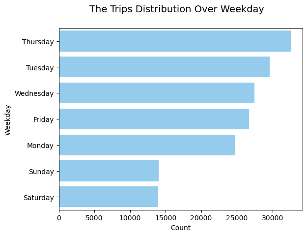

```python
# plot the trips distribution per weekday

weekday_order = df_ford['weekday_st'].value_counts().index
c= sb.countplot(data=df_ford, y='weekday_st', color='lightskyblue', order=weekday_order);
c.set_xlabel('Count')
c.set_ylabel('Weekday')
plt.suptitle("The Trips Distribution Over Weekday", fontsize=14);
```

### From above bar plot , we can note that the Thursday is the most popular days for bike trips. And the Sunday & Saturday are lowest days for bike rides.

## 2. What is the percentage bike rides per gender ?

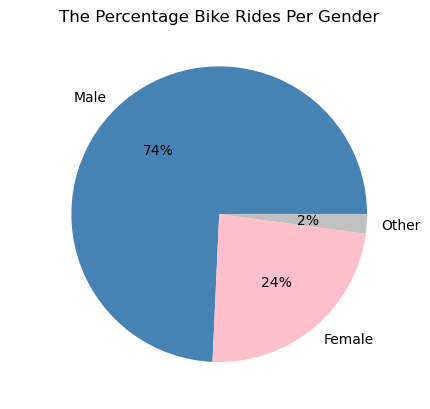

```python
gender_counts = df_ford['member_gender'].value_counts()
colors = ['steelblue', 'pink', 'silver']
def pie_gender_counts():
    gender_counts.plot(
    kind='pie',ylabel=" " ,title="The Percentage Bike Rides Per Gender",
  autopct='%1.0f%%', colors=colors);
pie_gender_counts()
```

### As we notice in the pie chart , most of the bike users are male with 74%and then female with 24% and lowest one other with 2% .

## 3. What is the percentage bike rides per users type ?

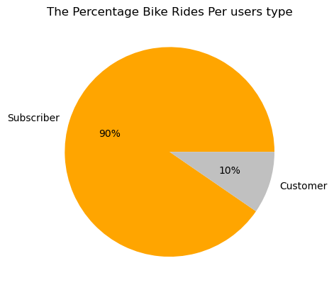

```python
# plot pie to show percentage bike rides per users type
user_counts = df_ford['user_type'].value_counts()
colors = ['orange', 'silver']
def pie_user_counts():
    user_counts.plot(
    kind='pie',ylabel=" " ,title="The Percentage Bike Rides Per users type",
  autopct='%1.0f%%', colors=colors);
pie_user_counts()
```

### As shown in the chart ,most bike rides users are Subscriber with 90% while the Customer represent 10% of bike rides users.

## 4. What is the most start stations and end stations by count bike rides ?

```python
start_stations_count= df_ford['start_station_name'].value_counts().sort_values(ascending=False)[:10]
```

```python
start_stations_count
```

```
Market St at 10th St                                         3610
San Francisco Caltrain Station 2  (Townsend St at 4th St)    3287
Berry St at 4th St                                           2856
Montgomery St BART Station (Market St at 2nd St)             2642
Powell St BART Station (Market St at 4th St)                 2548
San Francisco Caltrain (Townsend St at 4th St)               2441
San Francisco Ferry Building (Harry Bridges Plaza)           2382
Howard St at Beale St                                        2114
Powell St BART Station (Market St at 5th St)                 2110
Steuart St at Market St                                      2088
Name: start_station_name, dtype: int64
```

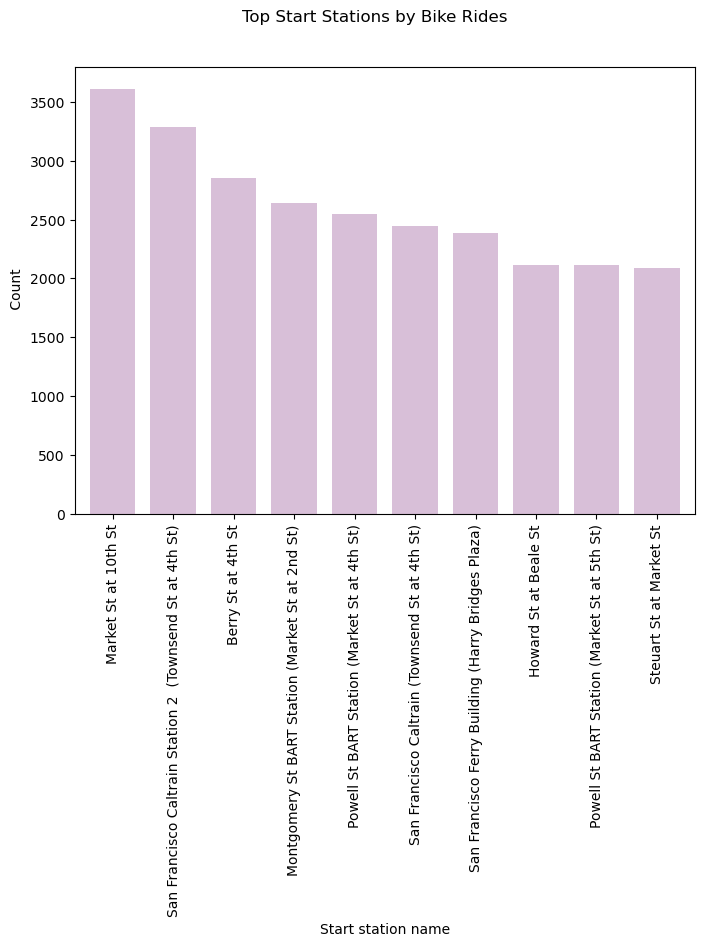

```python
# Plot a bar chart to show the top start stations
def bar_start_stations():

    start_stations_count.plot(kind='bar',ylabel=" Count",xlabel="Start station name",
            legend=False,
            width=0.75,
            figsize=(8,5.8),
            color='thistle',
            colormap='Paired')

plt.suptitle("Top Start Stations by Bike Rides");
bar_start_stations()
```

### As shown in the visualization , the top 10 start stations is Market St at 10th St with 3610 bike trips and next comes San Francisco Caltrain Station 2 (Townsend St at 4th St) with 3287 and last one comes Steuart St at Market St with about 2088.

```python
End_stations_count= df_ford['end_station_name'].value_counts().sort_values(ascending=False)[:10]
```

```python
End_stations_count
```

```
San Francisco Caltrain Station 2  (Townsend St at 4th St)    4521
Market St at 10th St                                         3660
Montgomery St BART Station (Market St at 2nd St)             3375
San Francisco Ferry Building (Harry Bridges Plaza)           2949
Powell St BART Station (Market St at 4th St)                 2777
San Francisco Caltrain (Townsend St at 4th St)               2729
Berry St at 4th St                                           2707
The Embarcadero at Sansome St                                2240
Steuart St at Market St                                      2187
Powell St BART Station (Market St at 5th St)                 2120
Name: end_station_name, dtype: int64
```

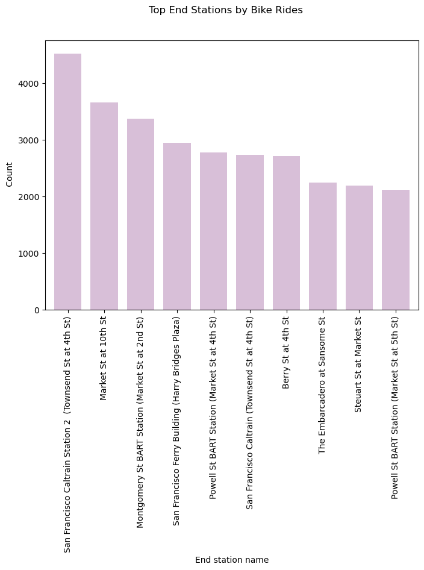

```python
# Plot a bar chart to show the top end stations
def bar_end_stations():

    End_stations_count.plot(kind='bar',ylabel=" Count",xlabel="End station name",  # Plot a bar chart
            legend=False,
            width=0.75,
            figsize=(8,5.8),
            color='thistle',
            colormap='Paired');
plt.suptitle("Top End Stations by Bike Rides");
bar_end_stations()
```

### As shown in the visualization , the top 10 end station is San Francisco Caltrain Station 2 (Townsend St at 4th St) with 4521 bike trips and next comes Market St at 10th St with 3660 and last one comes Powell St BART Station (Market St at 5th St) with about 2120.

## 5.What is the distribution of trip end time hours?

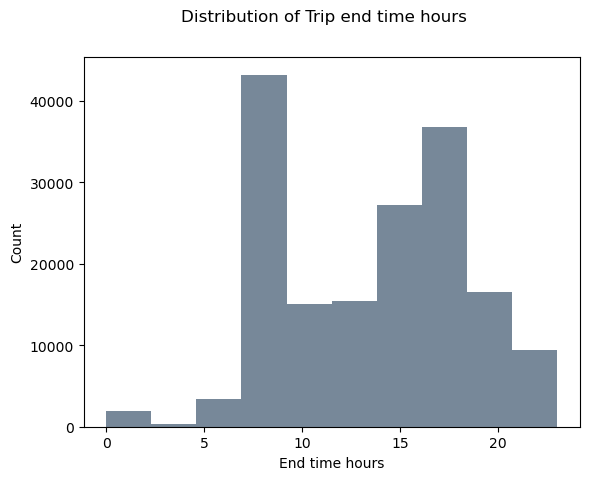

```python
# Plot histogram to show distribution of Trip end time hours
def trip_end_time():

    plt.hist(data = df_ford, x = 'hour_et', color='lightslategray');
plt.xlabel('End time hours')
plt.ylabel('Count')
plt.suptitle("Distribution of Trip end time hours");

trip_end_time()
```

### Of the features you investigated, were there any unusual distributions? Did you perform any operations on the data to tidy, adjust, or change the form of the data? If so, why did you do this?

- At the beginning I found a lot of missing values and I dealt with it by dropping it.
- I have created new columns such as (age - duration_min - duration_hours - weekday_st - day_st - hour_st - hour_et) to facilitate understand and analysis the data .
- I changed the data types in many columns :start_time - end_time - duration_min - duration_hours - age .
- I conducted a filter on the ages of users through the boxplot graph I concluded that the age range starts from 20 years to less than 145 years, but we note that the most of usres ages were between 18 years to 60 years, so I focused on this range of age.

## Bivariate Exploration

> In this section, investigate relationships between pairs of variables in your data. Make sure the variables that you cover here have been introduced in some fashion in the previous section (univariate exploration).

## 6.What is the average trips duration in minutes for each users type , gender and weekday ?

```python
df_ford['weekday_st'] = pd.Categorical(df_ford['weekday_st'], categories=
    ['Monday','Tuesday','Wednesday','Thursday','Friday','Saturday', 'Sunday'],
    ordered=True)
```

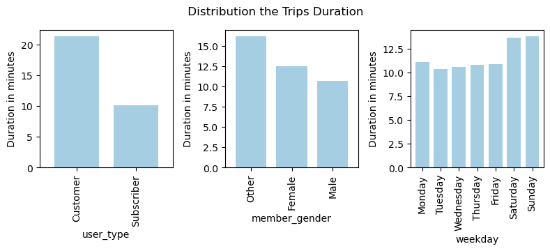

```python
# plot subplot bars to show average trips duration per users type , gender and weekday
plt.subplot(2, 3, 1)
df_ford.groupby('user_type')['duration_min'].mean().sort_values(ascending=False).plot(kind='bar',ylabel="Duration in minutes",xlabel="user_type",  # Plot a bar chart
            legend=False,
            width=0.75,
            figsize=(8,5.8),
            colormap='Paired')
plt.tight_layout();
plt.subplot(2, 3, 2)

df_ford.groupby('member_gender')['duration_min'].mean().sort_values(ascending=False).plot(kind='bar',ylabel="Duration in minutes",xlabel="member_gender",  # Plot a bar chart
            legend=False,
            width=0.75,
            figsize=(8,5.8),
            colormap='Paired')

plt.tight_layout();
plt.subplot(2, 3, 3)
plt.tight_layout();
df_ford.groupby('weekday_st')['duration_min'].mean().plot(kind='bar',ylabel="Duration in minutes",xlabel="weekday",  # Plot a bar chart
            legend=False,
            width=0.75,
            figsize=(8,5.8),
            colormap='Paired')

plt.suptitle(" Distribution the Trips Duration ")
plt.subplots_adjust(left=0.1,
                    bottom=0.1,
                    right=0.9,
                    top=0.9,
                    wspace=0.4,
                    hspace=0.4)
#fig = plt.figure(figsize=[14.70, 8.27]);
plt.tight_layout();

plt.show()
```

### To measure the effect of different factors such as user type, gender and days of the week on the average trips duration in minutes, we noted the following :the average duration minutes in the Subscriber with about 10 minutes and in the Customer with 21 minutes . In the gender, male has the lowest duration minutes with average duration about 11 minutes and next comes Female with about 12 minutes and the other comes in the last with about 16 minutes. The average duration of trips in the minutes varies slightly during the days of the week, as on Sunday and Saturday took average duration about 13 minutes and the rest of the week took about 11.

## 7. What are the highest start & end stations according to the average duration in minutes ?

```python
start_station_min = df_ford.groupby('start_station_name')['duration_min'].mean().sort_values(ascending=False)[:7]
```

```python
start_station_min
```

```
start_station_name
San Antonio Park                   49.533333
Palm St at Willow St               41.000000
Empire St at 7th St                37.473684
Foothill Blvd at 42nd Ave          31.681818
Foothill Blvd at Harrington Ave    30.047619
Fell St at Stanyan St              28.192000
San Carlos St at Market St         27.971429
Name: duration_min, dtype: float64
```

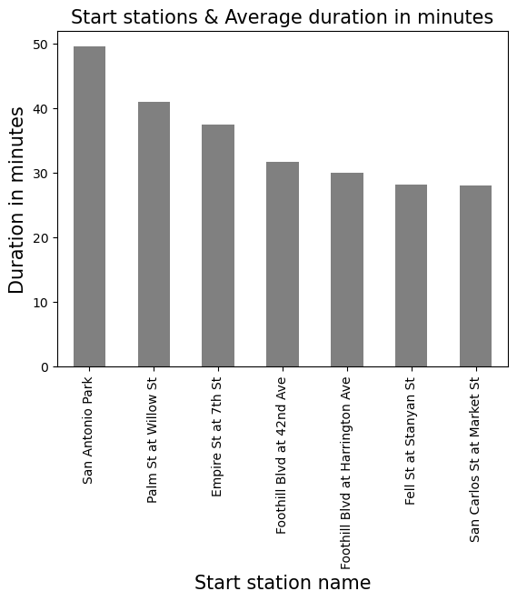

```python
#plot a bar chart to show Start stations & Average duration in minutes
start_station_min.plot(kind='bar',color='gray')
plt.title('Start stations & Average duration in minutes', fontsize=15)
plt.xlabel('Start station name', fontsize=15)
plt.ylabel('Duration in minutes', fontsize=15);
```

### As shown in the chart, the top start stations by average duration in minutes are San Antonio Park with about 49.5 min and next comes Palm St at Willow St with 41.0 min and and lowest one is San Carlos St at Market St with 27.9 min.

```python
end_station_min = df_ford.groupby('end_station_name')['duration_min'].mean().sort_values(ascending=False)[:7]
```

```python
end_station_min
```

```
end_station_name
16th St Depot                            433.000000
Willow St at Vine St                      58.400000
Lane St at Revere Ave                     33.413043
San Antonio Park                          31.444444
Fell St at Stanyan St                     30.791255
Backesto Park (Jackson St at 13th St)     30.000000
Lombard St at Columbus Ave                29.712190
Name: duration_min, dtype: float64
```

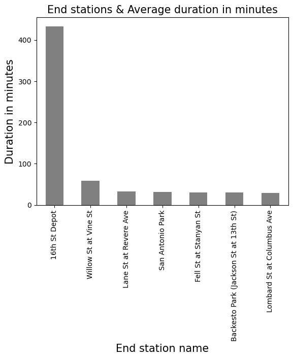

```python
#plot a bar chart to show End stations & Average duration in minutes
end_station_min.plot(kind='bar',color='gray')
plt.title('End stations & Average duration in minutes', fontsize=15)
plt.xlabel('End station name', fontsize=15)
plt.ylabel('Duration in minutes', fontsize=15);
```

### As you can see, 16th St Depot station comes first, with a big difference from the rest of the stations, by 433.0 minutes .And next comes Willow St at Vine St with 58.4 min .

## 8. What are the bike users average age in each weekday?

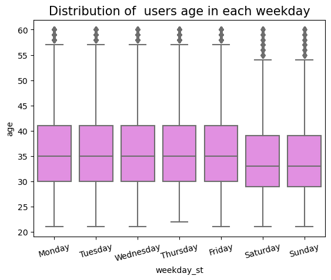

```python
# plot boxplot to show distribution of ages per weekday
def plot_age_weekday(data,x,y , title):
    sb.boxplot(data=data,x=x ,y=y , color ="violet")
    plt.xticks(rotation=15);
    plt.title(title , fontsize=15);
plot_age_weekday(data=df_ford, x='weekday_st', y='age', title="Distribution of  users age in each weekday")
```

```python
ssname_users_top = df_ford.groupby(['start_station_name', 'user_type']).size()[:10]
```

```python
ssname_users_top
```

```
start_station_name         user_type
10th Ave at E 15th St      Customer        3
                           Subscriber     52
10th St at Fallon St       Customer       23
                           Subscriber    310
10th St at University Ave  Customer       17
                           Subscriber    163
11th St at Bryant St       Customer       46
                           Subscriber    728
11th St at Natoma St       Customer       56
                           Subscriber    719
dtype: int64
```

```python
ssname_users_top  = ssname_users_top.reset_index(name='count')
```

```python
ssname_users_top
```

|  | start_station_name | user_type | count |
| --- | --- | --- | --- |
| 0 | 10th Ave at E 15th St | Customer | 3 |
| 1 | 10th Ave at E 15th St | Subscriber | 52 |
| 2 | 10th St at Fallon St | Customer | 23 |
| 3 | 10th St at Fallon St | Subscriber | 310 |
| 4 | 10th St at University Ave | Customer | 17 |
| 5 | 10th St at University Ave | Subscriber | 163 |
| 6 | 11th St at Bryant St | Customer | 46 |
| 7 | 11th St at Bryant St | Subscriber | 728 |
| 8 | 11th St at Natoma St | Customer | 56 |
| 9 | 11th St at Natoma St | Subscriber | 719 |

```python
ssname_users_top = ssname_users_top.pivot(index = 'start_station_name', columns = 'user_type', values = 'count')
ssname_users_top
```

| user_type start_station_name | Customer | Subscriber |
| --- | --- | --- |
| 10th Ave at E 15th St | 3 | 52 |
| 10th St at Fallon St | 23 | 310 |
| 10th St at University Ave | 17 | 163 |
| 11th St at Bryant St | 46 | 728 |
| 11th St at Natoma St | 56 | 719 |

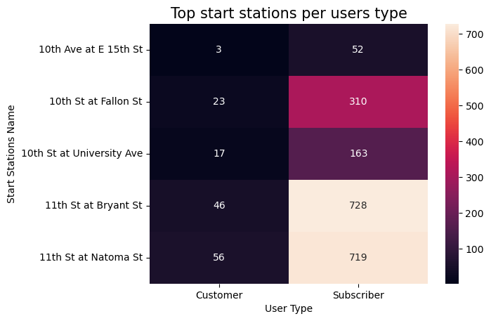

```python
# plot heatmap to show top start stations per  users type
sb.heatmap(ssname_users_top, annot = True, fmt = 'd');
plt.xlabel('User Type')
plt.ylabel('Start Stations Name')
plt.title('Top start stations per users type', fontsize=15);
```

## 10. What is the trips end times distribution in each gender?

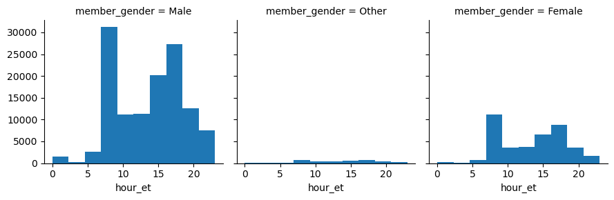

```python
# plot FacetGrid to show the relationship between  trips end times & gender
g = sb.FacetGrid(data = df_ford, col = 'member_gender')
g.map(plt.hist, "hour_et");
```

## 11.What are the most start stations in each Thursday?

```python
top_start_stations_name_each_Thursday= df_ford[df_ford['weekday_st']=='Thursday'].groupby('start_station_name')['start_station_id'].count().sort_values(ascending=False)[:7]
```

```python
top_start_stations_name_each_Thursday
```

```
start_station_name
San Francisco Caltrain Station 2  (Townsend St at 4th St)    771
Market St at 10th St                                         710
Berry St at 4th St                                           609
Montgomery St BART Station (Market St at 2nd St)             582
San Francisco Ferry Building (Harry Bridges Plaza)           494
San Francisco Caltrain (Townsend St at 4th St)               483
Howard St at Beale St                                        463
Name: start_station_id, dtype: int64
```

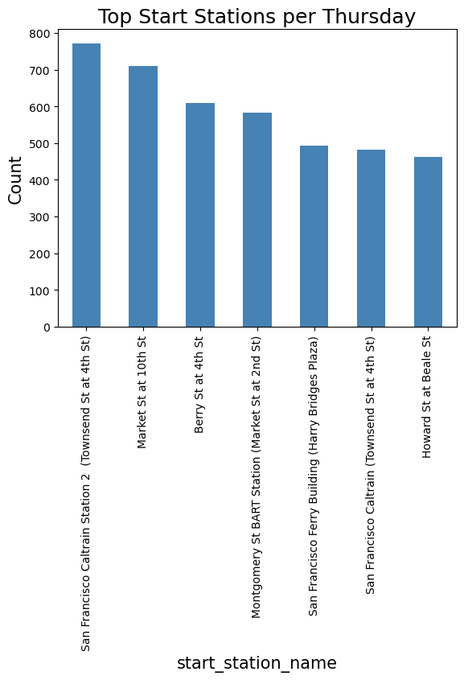

```python
# plot bar chart to show  the top start stations per Thursday
def start_stations_Thursday():
    top_start_stations_name_each_Thursday.plot(kind='bar',color='steelblue')
plt.title('Top Start Stations per Thursday', fontsize=18)
plt.xlabel('Start station name', fontsize=15)
plt.ylabel('Count', fontsize=15);
start_stations_Thursday()
```

### Did you observe any interesting relationships between the other features (not the main feature(s) of interest)?

I observed that the male users is very high but it got lower trip duration, the subscriber users are very high but it got lower trip duration than customer and the trip duration is so different between the start and end stations .

## Multivariate Exploration

> Create plots of three or more variables to investigate your data even further. Make sure that your investigations are justified, and follow from your work in the previous sections.

## 12.What is distribution of trip duration by users age per user type?

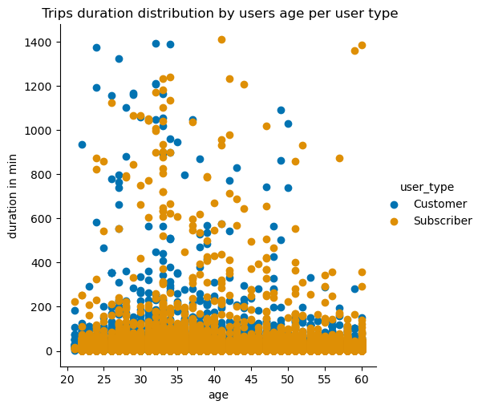

```python
# plot scatter to show the relationship between  users age & type and  trips duration
g = sb.FacetGrid(data = df_ford, hue = 'user_type', size = 5,
                 palette = 'colorblind')
g.map(plt.scatter, 'age', 'duration_min')
g.add_legend()
plt.title(' Trips duration distribution by users age per user type', fontsize=12 )
plt.xlabel('age', fontsize=10)
plt.ylabel('duration in min', fontsize=10);
```

### As we can see , most of bike users are between 20 to 60 years old and the customer users have longer trip duration than subscriber users.

## 13.What is distribution of trip duration in minute over weekday per user type?

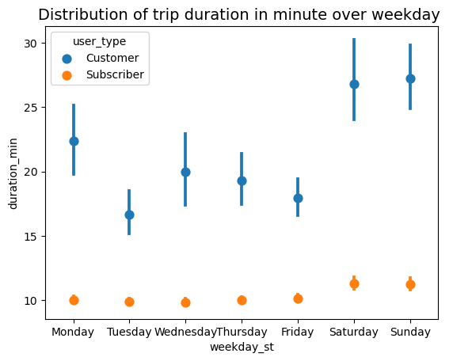

```python
def trip_duration_user():
    sb.pointplot(data=df_ford, x='weekday_st', y='duration_min', hue='user_type', linestyles="");
plt.xlabel('Day of Week');
plt.ylabel('Trip Duration in Minute');
plt.title('Distribution of trip duration in minute over weekday ', fontsize=14 );
trip_duration_user()
```

## 14. What is the bike users age distribution for each gender ?

```python
import seaborn as sns
```

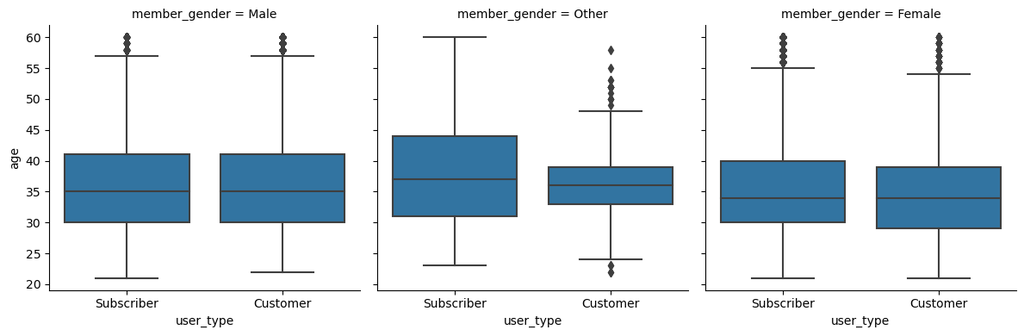

```python
# plot FacetGrid to show the relationship between  users type & age and  gender
#fig = plt.figure(figsize=[14.70, 8.27]);
#plt.tight_layout();
g = sb.FacetGrid(data = df_ford, col = 'member_gender', size = 4);
g.map(sb.boxplot, 'user_type', 'age');
```

## 15.What is distribution of trips by gender , bikeshare , weekday and user type ?

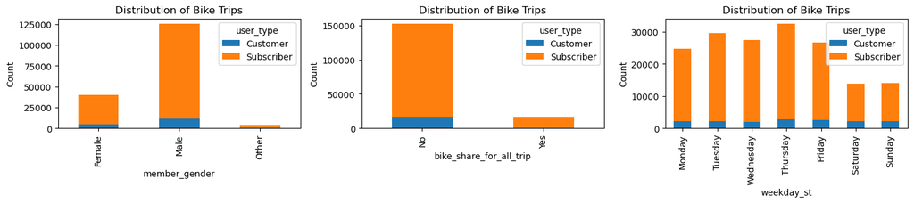

```python
# plot bar to show the relationship between trips & gender , bikeshare , weekday and user type
def trip_factors():
    Factors = ['member_gender', 'bike_share_for_all_trip', 'weekday_st']
    fig = plt.figure(figsize=[14.70, 8.27])
    for i, s in enumerate(Factors):
        ax = fig.add_subplot(3, 3, i+1)
        plt.title('Distribution of Bike Trips');
        plt.ylabel('Count');
        df_ford.groupby([s, 'user_type'])[s].count().unstack('user_type').plot(ax=ax, kind='bar', stacked=True )
        plt.tight_layout()

trip_factors()
```

### From above chart , we can notice that :

#### - Most bike rides users are Subscriber .

#### - Most bike rides users didn't sharing bike for all trips.

#### - Thursday has the highest number of bike rides trips.

### Talk about some of the relationships you observed in this part of the investigation. Were there features that strengthened each other in terms of looking at your feature(s) of interest?

Yes, through visualization, what we said earlier has been proven correct. Factors like : Gender , Users type , weekday and age are very effact in the trips number and trips duration . For Gender , male members is very high but them have the lowest trip duration. For Users type , most of users are Subscriber but have lowest trips duration. For weekday ,the number of trips and the duration of trips varies during the days of the week, as the highest day in the number of trips is Thursday while the Tuesday had the lowest trips duration. For age , most of bike users ages are between 20 to 60 years old and and the trips duration of them is very different.

### Were there any interesting or surprising interactions between features?

I was shocked when I found some older age users have low trip duration than younger.

```python
df_ford.to_csv('Ford_Gobike_Data_Exploration.csv')
```